# Midpoint

## Summary

### How committed is the Washington Government towards Renewable Energy?

Since 2001, Washington State had the highest share of renewable electricity supply out of total electricity supply in 2002 at 78.5017527 percent, while only an year before, it had the lowest share of renewable electricity supply out of total electricity supply in 2001 at 66.6903369 percent. This shows how quickly the share of renewable electricity supply out of total electricity supply in Washington State can change within a span of an year. Hence, to properly evaluate the Washington State’s commitment towards renewable energy, the average share over 2001-2018 gives a better indication than the highest and lowest amounts. At 73.2276179 percent, we can say that the state’s commitment towards renewable energy has been moderate, since the amount is right in between the highest and lowest percentages.

### How do Americans view Renewable Energy?

In the United States, California had the highest renewable energy consumption in 2018 at 1154.5 BTUs, while Delaware had the lowest at 8 BTUs. However, that’s an unfair comparison because densely populated states are likely to have a higher renewable energy consumption than that of less densely populated states. Hence, renewable energy consumption per total energy consumption would give us a better understanding as to how the people of each state view renewable energy. Now, Oregon is the highest at 44.4404687 percent, while Delaware is still the lowest at 3.6182723 percent.

## Aggregated Data

| Year | Nonrenewable Energy Consumed (MWh) | Renewable Energy Consumed (MWh) | Percentage Max Nonrenewable (%) | Percentage Max Renewable (w/ out Hydro.) (%) | Percentage Max Renewable (w/ Hydro.) (%) |
| --- | --- | --- | --- | --- | --- |
| 2001 | 29576290 | 47281044 | 17.24 | 1.22 | 59.66 |
| 2002 | 20563451 | 57139329 | 12.97 | 0.50 | 72.51 |
| 2003 | 26058617 | 54819899 | 17.73 | 0.54 | 66.58 |
| 2004 | 26482475 | 55252275 | 17.69 | 0.66 | 66.23 |
| 2005 | 27293922 | 56593480 | 17.71 | 0.70 | 65.97 |
| 2006 | 26140597 | 61273853 | 16.30 | 0.99 | 68.19 |
| 2007 | 27721913 | 60559010 | 16.84 | 0.62 | 67.06 |
| 2008 | 29209568 | 59978282 | 16.86 | 1.13 | 65.30 |
| 2009 | 30267574 | 58579317 | 16.51 | 0.66 | 64.40 |
| 2010 | 33675142 | 54840655 | 18.03 | 0.64 | 60.34 |
| 2011 | 22362698 | 68716253 | 14.16 | 1.12 | 73.39 |
| 2012 | 23895722 | 66711652 | 13.41 | 3.32 | 69.51 |
| 2013 | 29781757 | 61495382 | 14.81 | 3.13 | 63.62 |
| 2014 | 29146089 | 62576755 | 15.29 | 2.42 | 65.11 |
| 2015 | 30265891 | 58054210 | 16.29 | 2.30 | 62.62 |
| 2016 | 27107428 | 60297079 | 14.64 | 4.19 | 63.72 |
| 2017 | 26826925 | 67178673 | 13.40 | 2.84 | 67.70 |

`*This table assumes that all forms of sun, wind, water, waste, and biomass energy sources are renewable.

Over the course of 17 years, Washington’s renewable energy sources (excluding hydropower) generated <20% of the state’s energy. The table reveals that without hydropower, Washington can only sustain <5% of Washington’s energy requirement. This information is important as Gov. Jay Inslee pledged that Washington would achieve 100% carbon-neutral power by 2030. Without hydropower, Washington would have to look increase energy development efforts and look for alternative sources of power.

#### Table 2: *Energy Consumption Percentages in individual US States 2018*

This table assumes that all forms of sun, wind, water, and biomass energy sources are renewable.

| State | Nonrenewable Energy Consumed - Petroleum | Nonrenewable Energy Consumed - Coal + Natural Gas | Nonrenewable Energy Consumed - Nuclear | Renewable Energy - Biomass | Renewable Energy - Wind, Water, and Sun (WWS) | Percentage Renewable Energy (out of Total Energy Usage) - Biomass | Percentage Renewable Energy (out of Total Energy Usage) - WWS | Percentage Renewable Energy (out of Total Energy Usage) | Percentage Nonrenewable Energy - Petroleum | Percentage Nonrenewable Energy - Coal + Natural Gas | Percentage Nonrenewable Energy - Nuclear | Percentage Renewable Energy - Biomass | Percentage Renewable Energy - WWS |
| --- | --- | --- | --- | --- | --- | --- | --- | --- | --- | --- | --- | --- | --- |
| Alabama | 519.6 | 1148.1 | 412.6 | 193.4 | 104.9 | 8.13 | 4.41 | 12.54 | 24.98 | 55.19 | 19.83 | 64.81 | 35.15 |
| Alaska | 221.2 | 363.6 | 0.0 | 8.2 | 16.8 | 1.34 | 2.75 | 4.10 | 37.82 | 62.18 | 0.00 | 32.80 | 67.20 |
| Arizo | 539.5 | 732.1 | 325.1 | 38.9 | 139.5 | 2.19 | 7.86 | 10.05 | 33.79 | 45.85 | 20.36 | 21.79 | 78.15 |
| Arkansas | 329.9 | 671.0 | 133.0 | 93.5 | 30.3 | 7.43 | 2.41 | 9.84 | 29.09 | 59.18 | 11.73 | 75.53 | 24.48 |
| California | 3512.8 | 2240.7 | 190.4 | 296.9 | 857.5 | 4.18 | 12.08 | 16.26 | 59.10 | 37.70 | 3.20 | 25.72 | 74.27 |
| Colorado | 501.0 | 804.1 | 0.0 | 43.2 | 121.4 | 2.94 | 8.26 | 11.20 | 38.39 | 61.61 | 0.00 | 26.25 | 73.75 |
| Connecticut | 312.7 | 290.0 | 176.5 | 38.7 | 11.7 | 4.66 | 1.41 | 6.08 | 40.13 | 37.22 | 22.65 | 76.79 | 23.21 |
| Delaware | 109.4 | 103.7 | 0.0 | 6.1 | 1.9 | 2.76 | 0.86 | 3.62 | 51.34 | 48.66 | 0.00 | 76.25 | 23.75 |
| Florida | 1688.0 | 1838.9 | 306.5 | 251.8 | 65.7 | 6.07 | 1.58 | 7.65 | 44.03 | 47.97 | 8.00 | 79.31 | 20.69 |
| Georgia | 876.3 | 1099.5 | 359.3 | 247.5 | 55.0 | 9.38 | 2.09 | 11.47 | 37.53 | 47.09 | 15.39 | 81.85 | 18.19 |
| Hawaii | 247.2 | 14.6 | 0.0 | 10.7 | 20.5 | 3.65 | 7.00 | 10.65 | 94.42 | 5.58 | 0.00 | 34.41 | 65.92 |
| Idaho | 180.8 | 118.6 | 0.0 | 46.7 | 132.3 | 9.76 | 27.66 | 37.42 | 60.39 | 39.61 | 0.00 | 26.10 | 73.95 |
| Illinois | 1228.6 | 1832.1 | 1025.7 | 170.3 | 114.3 | 3.90 | 2.61 | 6.51 | 30.07 | 44.83 | 25.10 | 59.82 | 40.15 |
| India | 741.1 | 1876.1 | 0.0 | 126.0 | 59.8 | 4.50 | 2.13 | 6.63 | 28.32 | 71.68 | 0.00 | 67.78 | 32.17 |
| Iowa | 413.4 | 757.2 | 51.2 | 258.1 | 205.2 | 15.32 | 12.18 | 27.49 | 33.84 | 61.97 | 4.19 | 55.70 | 44.28 |
| Kansas | 345.6 | 549.1 | 95.9 | 46.6 | 173.6 | 3.85 | 14.34 | 18.18 | 34.89 | 55.43 | 9.68 | 21.15 | 78.80 |
| Kentucky | 604.1 | 1012.4 | 0.0 | 58.4 | 43.6 | 3.40 | 2.54 | 5.94 | 37.37 | 62.63 | 0.00 | 57.20 | 42.70 |
| Louisia | 1897.0 | 1998.5 | 179.3 | 140.2 | 14.7 | 3.31 | 0.35 | 3.66 | 46.55 | 49.05 | 4.40 | 90.45 | 9.48 |
| Maine | 173.6 | 50.5 | 0.0 | 108.2 | 52.3 | 28.14 | 13.60 | 41.74 | 77.47 | 22.53 | 0.00 | 67.46 | 32.61 |
| Maryland | 448.5 | 437.2 | 156.7 | 47.4 | 43.1 | 4.18 | 3.80 | 7.99 | 43.03 | 41.94 | 15.03 | 52.43 | 47.68 |
| Massachusetts | 561.5 | 452.7 | 46.4 | 63.8 | 41.4 | 5.47 | 3.55 | 9.02 | 52.94 | 42.68 | 4.37 | 60.65 | 39.35 |
| Michigan | 877.4 | 1516.9 | 318.7 | 179.0 | 71.5 | 6.04 | 2.41 | 8.45 | 32.34 | 55.91 | 11.75 | 71.49 | 28.55 |
| Minnesota | 582.6 | 776.0 | 152.7 | 183.5 | 118.6 | 10.12 | 6.54 | 16.66 | 38.55 | 51.35 | 10.10 | 60.72 | 39.25 |
| Mississippi | 465.2 | 651.4 | 72.3 | 72.8 | 4.1 | 5.75 | 0.32 | 6.08 | 39.13 | 54.79 | 6.08 | 94.79 | 5.34 |
| Missouri | 610.7 | 998.0 | 111.4 | 71.8 | 36.7 | 3.93 | 2.01 | 5.93 | 35.50 | 58.02 | 6.48 | 66.18 | 33.82 |
| Monta | 172.7 | 243.1 | 0.0 | 22.8 | 124.2 | 4.05 | 22.06 | 26.11 | 41.53 | 58.47 | 0.00 | 15.50 | 84.43 |
| Nebraska | 242.3 | 460.5 | 58.9 | 128.8 | 64.7 | 13.48 | 6.77 | 20.26 | 31.81 | 60.46 | 7.73 | 66.56 | 33.44 |
| Nevada | 259.8 | 345.8 | 0.0 | 15.7 | 101.6 | 2.17 | 14.05 | 16.23 | 42.90 | 57.10 | 0.00 | 13.38 | 86.62 |
| New Hampshire | 155.2 | 59.3 | 105.2 | 45.0 | 17.1 | 11.79 | 4.48 | 16.27 | 48.55 | 18.55 | 32.91 | 72.46 | 27.54 |
| New Jersey | 935.1 | 816.3 | 334.4 | 57.7 | 29.2 | 2.66 | 1.34 | 4.00 | 44.83 | 39.14 | 16.03 | 66.40 | 33.60 |
| New Mexico | 259.4 | 418.0 | 0.0 | 23.1 | 72.2 | 2.99 | 9.35 | 12.34 | 38.29 | 61.71 | 0.00 | 24.26 | 75.84 |
| New York | 1328.9 | 1410.4 | 448.7 | 165.2 | 325.1 | 4.49 | 8.84 | 13.33 | 41.68 | 44.24 | 14.07 | 33.69 | 66.31 |
| North Caroli | 838.4 | 924.4 | 439.9 | 149.3 | 123.8 | 6.03 | 5.00 | 11.03 | 38.06 | 41.97 | 19.97 | 54.65 | 45.31 |
| North Dakota | 189.9 | 537.8 | 0.0 | 32.9 | 127.7 | 3.70 | 14.38 | 18.08 | 26.10 | 73.90 | 0.00 | 20.50 | 79.56 |
| Ohio | 1110.5 | 1929.7 | 191.5 | 134.2 | 24.3 | 3.96 | 0.72 | 4.68 | 34.36 | 59.71 | 5.93 | 84.62 | 15.32 |
| Oklahoma | 538.7 | 1005.9 | 0.0 | 49.8 | 268.1 | 2.67 | 14.39 | 17.07 | 34.88 | 65.12 | 0.00 | 15.67 | 84.33 |
| Oregon | 332.9 | 288.2 | 0.0 | 95.0 | 401.8 | 8.50 | 35.94 | 44.44 | 53.60 | 46.40 | 0.00 | 19.12 | 80.88 |
| Pennsylvania | 1203.2 | 2157.3 | 872.7 | 172.6 | 78.6 | 3.85 | 1.75 | 5.60 | 28.42 | 50.96 | 20.62 | 68.71 | 31.29 |
| Rhode Island | 84.4 | 104.7 | 0.0 | 7.3 | 2.7 | 3.67 | 1.36 | 5.02 | 44.63 | 55.37 | 0.00 | 73.00 | 27.00 |
| South Caroli | 529.4 | 542.0 | 551.2 | 128.5 | 34.9 | 7.19 | 1.95 | 9.15 | 32.63 | 33.40 | 33.97 | 78.59 | 21.35 |
| South Dakota | 114.4 | 123.1 | 0.0 | 64.8 | 84.7 | 16.74 | 21.89 | 38.63 | 48.17 | 51.83 | 0.00 | 43.34 | 56.66 |
| Tennessee | 719.5 | 655.3 | 378.2 | 109.3 | 96.7 | 5.58 | 4.94 | 10.52 | 41.04 | 37.38 | 21.57 | 53.06 | 46.94 |
| Texas | 6998.9 | 5753.4 | 430.6 | 270.8 | 738.3 | 1.91 | 5.20 | 7.11 | 53.09 | 43.64 | 3.27 | 26.84 | 73.17 |
| Utah | 303.4 | 526.6 | 0.0 | 16.9 | 44.4 | 1.90 | 4.98 | 6.88 | 36.55 | 63.45 | 0.00 | 27.57 | 72.43 |
| Vermont | 76.3 | 14.2 | 0.0 | 27.0 | 17.2 | 20.04 | 12.77 | 32.81 | 84.31 | 15.69 | 0.00 | 61.09 | 38.91 |
| Virginia | 776.4 | 816.2 | 305.8 | 155.5 | 26.0 | 7.48 | 1.25 | 8.73 | 40.90 | 42.99 | 16.11 | 85.67 | 14.33 |
| Washington | 801.3 | 396.0 | 101.5 | 145.9 | 810.9 | 6.47 | 35.95 | 42.42 | 61.70 | 30.49 | 7.81 | 15.25 | 84.75 |
| West Virginia | 218.6 | 884.7 | 0.0 | 20.6 | 33.0 | 1.78 | 2.85 | 4.63 | 19.81 | 80.19 | 0.00 | 38.36 | 61.45 |
| Wisconsin | 543.1 | 927.4 | 105.9 | 161.0 | 38.6 | 9.07 | 2.17 | 11.24 | 34.45 | 58.83 | 6.72 | 80.66 | 19.34 |
| Wyoming | 162.6 | 630.6 | 0.0 | 8.4 | 46.6 | 0.99 | 5.49 | 6.49 | 20.50 | 79.50 | 0.00 | 15.30 | 84.88 |

| Year | Nonrenewable Energy Consumed - Petroleum | Nonrenewable Energy Consumed - Coal + Natural Gas | Nonrenewable Energy Consumed - Nuclear | Renewable Energy - Biomass | Renewable Energy - Wind, Water, and Sun (WWS) | Percentage Renewable Energy (out of Total Energy Usage) - Biomass | Percentage Renewable Energy (out of Total Energy Usage) - WWS | Percentage Renewable Energy (out of Total Energy Usage) | Percentage Nonrenewable Energy - Petroleum | Percentage Nonrenewable Energy - Coal + Natural Gas | Percentage Nonrenewable Energy - Nuclear | Percentage Renewable Energy - Biomass | Percentage Renewable Energy - WWS |
| --- | --- | --- | --- | --- | --- | --- | --- | --- | --- | --- | --- | --- | --- |
| 1987 | 634600 | 231792 | 57728 | 122823 | 238250 | 9.56 | 18.54 | 28.09 | 68.67 | 25.08 | 6.25 | 34.02 | 65.98 |
| 1988 | 667026 | 249694 | 63616 | 127760 | 233749 | 9.52 | 17.42 | 26.94 | 68.04 | 25.47 | 6.49 | 35.34 | 64.66 |
| 1989 | 690243 | 264638 | 64745 | 108569 | 244408 | 7.91 | 17.81 | 25.72 | 67.70 | 25.95 | 6.35 | 30.76 | 69.24 |
| 1990 | 691603 | 253191 | 60762 | 93715 | 298801 | 6.70 | 21.37 | 28.08 | 68.78 | 25.18 | 6.04 | 23.88 | 76.12 |
| 1991 | 693198 | 268480 | 44346 | 74222 | 305198 | 5.36 | 22.03 | 27.39 | 68.90 | 26.69 | 4.41 | 19.56 | 80.44 |
| 1992 | 755697 | 286856 | 59605 | 95669 | 233497 | 6.68 | 16.31 | 23.00 | 68.57 | 26.03 | 5.41 | 29.06 | 70.94 |
| 1993 | 699776 | 327420 | 74946 | 96782 | 230043 | 6.77 | 16.10 | 22.87 | 63.49 | 29.71 | 6.80 | 29.61 | 70.39 |
| 1994 | 720149 | 370060 | 70444 | 96598 | 224115 | 6.52 | 15.13 | 21.65 | 62.05 | 31.88 | 6.07 | 30.12 | 69.88 |
| 1995 | 738977 | 334264 | 72938 | 90390 | 281860 | 5.95 | 18.56 | 24.52 | 64.47 | 29.16 | 6.36 | 24.28 | 75.72 |
| 1996 | 730683 | 374810 | 58691 | 89758 | 336508 | 5.64 | 21.16 | 26.80 | 62.76 | 32.20 | 5.04 | 21.06 | 78.94 |
| 1997 | 748214 | 348606 | 65526 | 94302 | 355786 | 5.85 | 22.07 | 27.91 | 64.37 | 29.99 | 5.64 | 20.95 | 79.05 |
| 1998 | 710018 | 406783 | 72556 | 87269 | 272671 | 5.63 | 17.60 | 23.23 | 59.70 | 34.20 | 6.10 | 24.25 | 75.75 |
| 1999 | 721275 | 399137 | 63598 | 89181 | 331252 | 5.56 | 20.65 | 26.20 | 60.92 | 33.71 | 5.37 | 21.21 | 78.79 |
| 2000 | 744993 | 403809 | 89744 | 89316 | 274146 | 5.58 | 17.11 | 22.69 | 60.15 | 32.60 | 7.25 | 24.57 | 75.43 |
| 2001 | 720483 | 421854 | 86159 | 92755 | 187015 | 6.15 | 12.40 | 18.55 | 58.65 | 34.34 | 7.01 | 33.15 | 66.85 |
| 2002 | 694675 | 341326 | 94484 | 87737 | 271172 | 5.89 | 18.21 | 24.10 | 61.45 | 30.19 | 8.36 | 24.45 | 75.55 |
| 2003 | 684068 | 374046 | 79360 | 95750 | 251138 | 6.45 | 16.92 | 23.37 | 60.14 | 32.88 | 6.98 | 27.60 | 72.40 |
| 2004 | 695576 | 382111 | 93660 | 92592 | 251750 | 6.11 | 16.61 | 22.72 | 59.38 | 32.62 | 8.00 | 26.89 | 73.11 |
| 2005 | 709503 | 384451 | 86016 | 81278 | 251020 | 5.37 | 16.60 | 21.97 | 60.13 | 32.58 | 7.29 | 24.46 | 75.54 |
| 2006 | 730954 | 340184 | 97341 | 103736 | 290212 | 6.64 | 18.57 | 25.21 | 62.56 | 29.11 | 8.33 | 26.33 | 73.67 |
| 2007 | 764277 | 375166 | 85051 | 79079 | 293162 | 4.95 | 18.36 | 23.31 | 62.42 | 30.64 | 6.95 | 21.24 | 78.76 |
| 2008 | 717257 | 401686 | 96886 | 77274 | 301046 | 4.85 | 18.88 | 23.73 | 58.99 | 33.04 | 7.97 | 20.43 | 79.57 |
| 2009 | 694489 | 403787 | 69385 | 84333 | 283837 | 5.49 | 18.48 | 23.97 | 59.48 | 34.58 | 5.94 | 22.91 | 77.09 |
| 2010 | 691349 | 389805 | 96588 | 107573 | 279443 | 6.87 | 17.86 | 24.73 | 58.70 | 33.10 | 8.20 | 27.80 | 72.20 |
| 2011 | 688298 | 329212 | 50293 | 104436 | 374329 | 6.75 | 24.20 | 30.96 | 64.46 | 30.83 | 4.71 | 21.81 | 78.19 |
| 2012 | 701992 | 314603 | 97808 | 101315 | 368324 | 6.40 | 23.25 | 29.65 | 62.99 | 28.23 | 8.78 | 21.57 | 78.43 |
| 2013 | 687137 | 402795 | 88408 | 107981 | 333831 | 6.66 | 20.60 | 27.27 | 58.31 | 34.18 | 7.50 | 24.44 | 75.56 |
| 2014 | 677880 | 396714 | 99332 | 108558 | 340716 | 6.69 | 20.99 | 27.68 | 57.74 | 33.79 | 8.46 | 24.16 | 75.84 |
| 2015 | 722280 | 386011 | 85347 | 113296 | 317043 | 6.98 | 19.52 | 26.50 | 60.51 | 32.34 | 7.15 | 26.33 | 73.67 |
| 2016 | 799689 | 378231 | 100674 | 122969 | 342516 | 7.05 | 19.64 | 26.69 | 62.54 | 29.58 | 7.87 | 26.42 | 73.58 |
| 2017 | 774284 | 413005 | 85013 | 119159 | 345410 | 6.86 | 19.89 | 26.75 | 60.86 | 32.46 | 6.68 | 25.65 | 74.35 |

This table tracks the energy consumption per billion BTUs. Over the last 30 years, it is observed that the US’s renewable energy production fluctuates around the 20-30% range (see percentage renewable energy (out of total)). The renewable energy consumption grows relative to the increase in total energy consumption. Nuclear energy consumption is comparable to biomass energy consumption, whereas wind, water and sun energy (WWS) consumption is greater than both. The US may shift their focus to expanding multiple energy sources like nuclear energy and WWS to meet and hopefully completely fulfill the growing demand for energy.

## Three Charts

### 1. Scatter plot of Washington’s Energy Usage per Type from 2001 - 2017

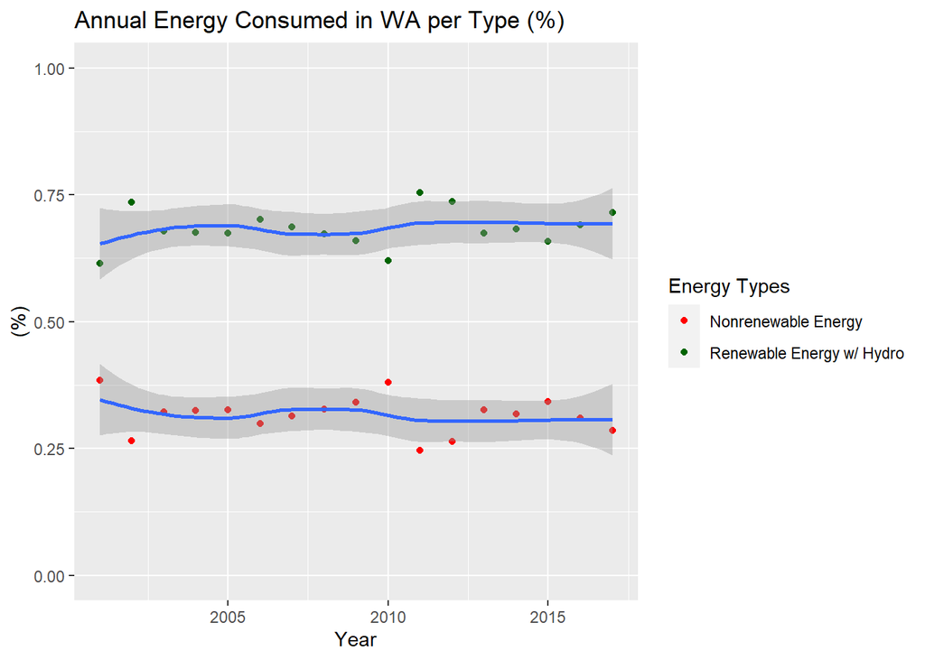

The scatter plot precisely tracks the trend of both nonrenewable and renewable energy consumption in WA to see whether sufficients improvements have been made. We are making this chart to verify whether Washington is on track to achieve 100% carbon-neutral power by 2030. The plot depicts an increase in renewable energy sources, however, it flatlines from 2013-2017. Renewable energy points are seen to have a steady increase in 2015-2017. The trend line hints that renewable energy production is increasing, but only steadily.

### 2. Grouped Bar plot of Washington vs US Average’s renewable energy consumption

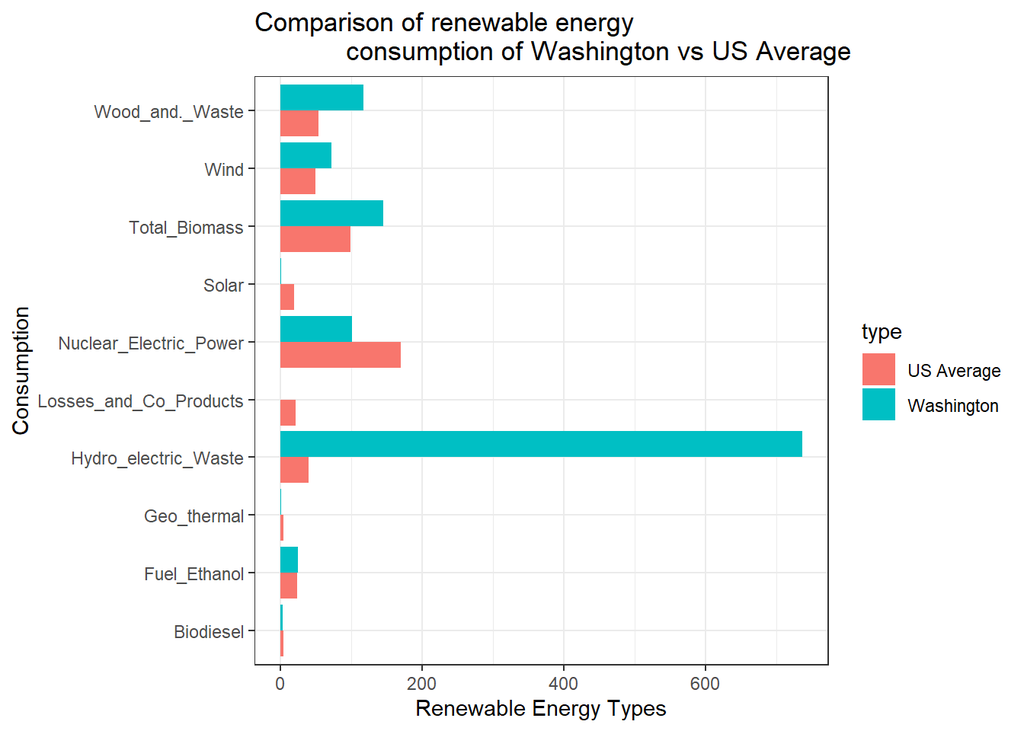

This is a grouped bar plot of Washington energy consumption vs US average (without Washington State) renewable energy consumption. The purpose of this chart is to understand how Washington State is doing and to check whether we are on course with our consumption of renewable energy when compared to the rest of the states. It could be easily observed that Washington on average uses more renewable energy.

### 3. Map of renewable energy consumption percentage

[interactive chart not shown]

This map shows the percentage of renewable energy being consumed by each state. The bigger the circle, the larger the percentage. Additionally, when you click on a blue circle, you will get a pop-up box which shows the exact percentage. The purpose of this map is to allow the reader to visually compare different U.S states with each other. The map lets the reader comprehend the information in a simplistic manner. Nonetheless, one key inference from this map is that Washington has one of the highest percentage of renewable energy usage in the United States.